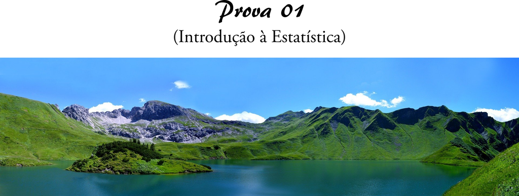

## Informações Relevantes

Usaremos algumas bases de dados reais para realização dessa prova. Por conta disso, o tempo de resolução será extendido, visto que algumas dessas bases possuem mais de 50 MB, o que pode ocasionar demora no *download*.

As bases de dados serão retiradas de nosso repositório do GitHub e do *site* brasil.io.

Faça o *download* dos seguintes conjuntos de dados:

1. [Salário de Magistrados](https://drive.google.com/u/0/uc?id=1FCdmXKf35dTtmnZQ1XhQPl7sF1MxX7WV&export=download);
2. [Cursos e notas de corte do PROUNI 2018](https://drive.google.com/u/0/uc?id=1lnqYHylEWT8cN6vPZ-NRR8KfFAPNq43r&export=download)
3. [Peixes do Rio Madeira](https://github.com/icaro-freire/dados_csv/blob/main/dados/csv/peixes_rio_madeira.csv)

O uso do *software* `R` é suficiente, mas não necessário. Ou seja, você pode usar qualquer outro *software* que estiver mais familiarizado, todavia, as dicas que serão dadas em algumas questões abaixo, serão voltadas para os usuários do `R`.

## Identificação

**Aluno:** Naiara Ferreira de Jesus

**Data:** (18/ 09/ 2021)

## Questões (Soluções)

### I. Sobre o *dataset* `peixes_rio_madeira.csv`

**Questão 01.** Considerando a variável `ordem`, responda:

1. Faça uma distribuição de frequência da variável `ordem`, ordenando os valores numéricos de forma crescente.
2. Qual `ordem` de peixe foi a mais identificada? Quantas foram as observações?
3. Quantos não foram identificados na variável `ordem`?
4. Faça um gráfico de barras para representar a variável ordem, nesse *dataset*.

### Carregando dataset

```r
dados_peixes <- read.csv("dados/peixes_rio_madeira.csv")
```

**a)** Visualizando a frequência

```r
dados_peixes %>%
  count(dados_peixes$ordem)
```

| dados_peixes$ordem | n |
| --- | --- |
| Acanthuriformes | 1602 |
| Beloniformes | 5 |
| Characiformes | 64356 |
| Cichliformes | 1947 |
| Clupeiformes | 2821 |
| Gymnotiformes | 693 |
| Lepidosireniformes | 2 |
| Myliobatiformes | 41 |
| NÃ£o identificado | 17 |
| Osteoglossiformes | 433 |

[output cut: 2 more lines]

**b)** A ordem mais identificada foi Characiformes,com 64356 observações.

**c)** 17 Ordens não foram identificados.

**d)** Gráfico de barras para representar a variável ordem

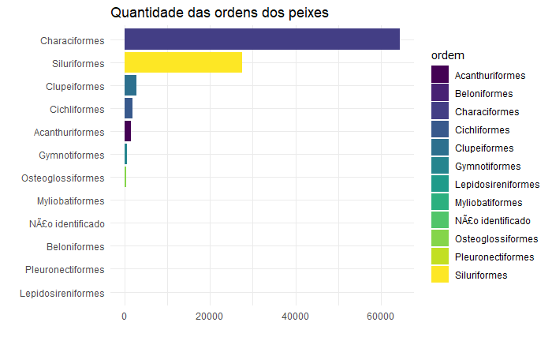

```r
dados_peixes%>%
  count(ordem) %>%
  mutate(prop = n / sum(n)) %>%
  ggplot() +
  aes(x = n, y = fct_reorder(ordem, n), fill = ordem) +
  geom_col() +
  scale_fill_viridis_d() +
  labs(
    title = "Quantidade das ordens dos peixes",
    x = "",
    y = ""
  ) +
  theme_minimal()
```

```r
NA
```

**Questão 02.** Dentre os peixes que foram coletados da bacia do “Rio Guaporé”, após a seleção da `ordem` e do `peso_g`, bem como a eliminação dos elementos não identificados; deseja-se comparar qual das ordens é a mais **homogênea**, no que se refere ao seu peso. Para isso, é necessário comparar a variabilidade do `peso_g` em relação à média. Se a média é igual em cada ordem, usamos o **desvio padrão**. Todavia, se a média em cada ordem é diferente, precisamos padronizar essa medida; e, nesse caso, usamos o **coeficiente de variação** (cv), em porcentagem. Quanto menor a porcentagem do `cv`, mais homogênea é a distribuição do `peso_g`. Define-se:
$$\text{cv} = \frac{\text{desvio padrão}}{média}\cdot 100$$

1. Qual medida de variabilidade é mais adequada para essa situação?
2. Determine qual das ordens dos peixes da bacia do Rio Guaporé possui distribuição de peso mais homogênea.

### Solução

calculando a média

```r
dados_peixes %>%
  group_by(ordem)%>%
  summarise(media_peso = mean(peso_g, na.rm = TRUE))
```

| ordem | media_peso |
| --- | --- |
| Acanthuriformes | 555.9674 |
| Beloniformes | 13.6000 |
| Characiformes | 164.6588 |
| Cichliformes | 209.9167 |
| Clupeiformes | 263.2978 |
| Gymnotiformes | 173.9738 |
| Lepidosireniformes | 1073.0000 |
| Myliobatiformes | 2396.0294 |
| NÃ£o identificado | 469.5294 |
| Osteoglossiformes | 643.5313 |

[output cut: 2 more lines]

**a)** A medidade de variabilidade mais adequada é a medida do coeficiente de variação visto que as médias são distintas.

**b)** A ordem que possui distribuição mais homogênea é a Clupeiformes, com o coeficiente de variação de 78.23765.

calculando o coeficiente de variação

```r
dados_peixes %>%

group_by(ordem) %>%
  filter(bacia == "Rio GuaporÃ©") %>%
  summarise(media_peso =
    mean(peso_g,  na.rm = TRUE),
    desvio_peso = sd(peso_g,  na.rm = TRUE),
    cv = (desvio_peso/media_peso)*100)
```

| ordem | media_peso | desvio_peso | cv |
| --- | --- | --- | --- |
| Acanthuriformes | 198.00000 | 249.60168 | 126.06146 |
| Characiformes | 65.84589 | 106.35040 | 161.51411 |
| Cichliformes | 178.80000 | 242.39976 | 135.57033 |
| Clupeiformes | 300.14815 | 234.82886 | 78.23765 |
| Gymnotiformes | 80.61111 | 79.83779 | 99.04068 |
| Myliobatiformes | NaN | NA | NA |
| Siluriformes | 92.32534 | 206.16689 | 223.30477 |

**Questão 03.** No que se refere à variável `sexo`, recodifique-a (coloque o nome como `sexo_recode`) para que você possa filtrar aspenas os sexos “Macho” e “Fêmea”, depois responda:

1. Qual o aumento, em porcentagem, devemos dar à quantidade de machos para que possua a mesma quantidade referente às fêmeas?
2. Selecione as variáveis `peso_g` e `sexo_recode`, dentre os peixes identificados por “Macho” e “Fêmea”, qual o sexo do peixe com maior peso?
3. Faça um gráfico que represente de forma adequada a quantidade de machos e fêmeas, facetando tal gráfico na variável `bacia`.

### Solução

Recodificando a variável

```r
dados_peixes <- dados_peixes %>%
  rename(sexo_recode = sexo)
```

```r
dados_peixes %>%
  count(sexo_recode)
```

| sexo_recode | n |
| --- | --- |
| fêmea | 3 |
| Fêmea | 28328 |
| Macho | 21469 |
| Não coletado | 49570 |

```r
dados_peixes %>%
  select(sexo_recode,peso_g) %>%
  filter(sexo_recode!= "NÃ£o coletado") %>%
  arrange(desc(peso_g)
)
```

| sexo_recode | peso_g |
| --- | --- |
| Fêmea | 14600 |
| Fêmea | 12405 |
| Fêmea | 11600 |
| Fêmea | 11230 |
| Fêmea | 10770 |
| Fêmea | 10545 |
| Fêmea | 10030 |
| Fêmea | 9696 |
| Fêmea | 9200 |
| Fêmea | 9110 |

[output cut: 990 more lines]

**c)** Gráfico que representa a quantidade de peixes por bacia:

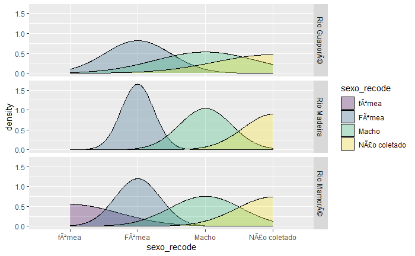

```r
dados_peixes %>%
  ggplot() +
  aes(x = sexo_recode) +
  geom_density(aes(fill = sexo_recode), alpha = 0.3) +
  facet_grid(bacia~.) +
  scale_fill_viridis_d()
```

**Questão 04.** Faça um gráfico de pontos relacionando o peso (em kilogramas) e o comprimento (em metros), destacando a curva que melhor se adequa aos pontos, colorindo segundo a variável `ordem`. Depois, facete-o por `bacia`. Para ajudar, complete adequadamente o código abaixo (considere a variável `dados_peixes`, o conjunto de dados em questão), substituindo o símbolo “❓❓” pela variável conveniente.

```r
dados_peixe %>%
  select(ordem, peso_g, cp_cm) %>%
  ggplot() +
  aes(x=️ ❓❓/1000, y = ❓❓/100) +
  geom_point(aes(color = ❓❓), alpha = 0.5) +
  facet_grid(❓❓~.) +
  geom_smooth()
```

1. A curva que se adapta aos pontos é (praticamente) a mesma em cada bacia?
2. Qual a sua interpretação para esse fato (dica: pesquise sobre a curva de “crescimento logístico” aplicada ao crescimento de população - no caso, de peixes)?

### Solução

rodadando o código

```
Warning: Removed 1372 rows containing non-finite values (stat_smooth).
Warning: Removed 1372 rows containing missing values (geom_point).
```

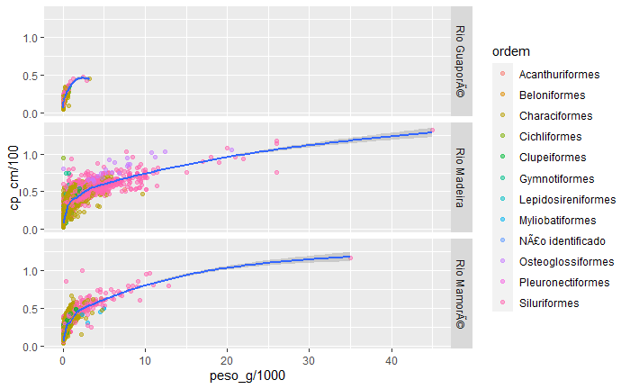

```r
dados_peixes %>%
  select(ordem, peso_g, cp_cm,bacia) %>%
  ggplot() +
  aes(x= peso_g /1000, y = cp_cm/100) +
  geom_point(aes(color = ordem), alpha = 0.5) +
  facet_grid(bacia~.) +
  geom_smooth()
```

```r
NA
```

**a)** Sim.

**b)** Ela possui um crescimento asim rapído assim como o exponencial,porém chega um ponto que comeca a ter uma ocilação entre queda e aumento dos pesos devido ao ambiente que os peixes vivem.

### II. Sobre o *dataset* `contracheque.csv`

**Questão 05.** Qual o maior rendimento líquido registrado nesse *dataset*?

### Solução

carregando dataset

```r
dados_contracheque <- read.csv("dados/contracheque.csv")
```

```r
  summary(dados_contracheque$rendimento_liquido)
```

```
   Min. 1st Qu.  Median    Mean 3rd Qu.    Max.    NA's
 -34542   20214   27270   30011   38139 7267672    1433
```

**Questão 06.** Sabendo-se que o teto constitucional do funcionalismo público é de $$ 39.293,32 $, determine quantos magistrados receberam acima desse valor.

1. Quantos magistrados ganharam acima de $\text{R}\$ 100.000,00$ ?
2. Qual `tribunal` possui maior variabilidade?

### Solução

8208 nagistrados receberam acima de $\text{R}\$39.293,32$

```r
dados_contracheque %>%
  select(retencao_por_teto_constitucional)%>%
 filter(retencao_por_teto_constitucional > 39.29332)%>%
 count()
```

| n |
| --- |
| 8208 |

**a)** 8093 magistrados receberam acima de $\text{R}\$100.000,00$.

```r
dados_contracheque %>%
  select(retencao_por_teto_constitucional)%>%
 filter(retencao_por_teto_constitucional > 100.00000)%>%
 count()
```

| n |
| --- |
| 8093 |

**b)** O tribunal com maior variabilidade é o Tribunal de Justiça de São Paulo, pois tem o maior coeficiente de variação.

```r
dados_contracheque %>%
group_by(tribunal)%>%
  summarise(
    media_retencao =
    mean(retencao_por_teto_constitucional,  na.rm = TRUE),
    desvio_rtptc = sd(retencao_por_teto_constitucional,  na.rm = TRUE),
    cv = (desvio_rtptc/media_retencao)*100) %>%
arrange(desc(cv))
```

| tribunal | media_retencao | desvio_rtptc | cv |
| --- | --- | --- | --- |
| Tribunal de Justiça de São Paulo | 3.6719808 | 149.1210539 | 4061.05207 |
| Tribunal Regional do Trabalho da 3ª Região | 3.1471613 | 71.2922212 | 2265.28651 |
| Tribunal Regional do Trabalho da 4ª Região (RS) | 5.9212982 | 131.4741558 | 2220.36033 |
| Tribunal Regional do Trabalho da 3ª Região (MG) | 2.6512857 | 58.6887111 | 2213.59436 |
| Tribunal de Justiça de Minas Gerais | 12.0832917 | 266.9071002 | 2208.89397 |
| Tribunal Regional do Trabalho da 3ª Região(MG) | 4.2362343 | 92.5691814 | 2185.17614 |
| Tribunal Regional do Trabalho da 4ª Região | 6.3950353 | 139.0988635 | 2175.10706 |
| Tribunal Regional do Trabalho da 4ª Região(RS) | 6.5137288 | 141.6200226 | 2174.17744 |
| Tribunal de Justiça do Paraná | 14.6462539 | 238.1626826 | 1626.09964 |
| Tribunal de Justiça de Pernambuco | 19.5953953 | 309.0754213 | 1577.28597 |

[output cut: 118 more lines]

### Sobre o *dataset* `cursos_prouni.csv`

**Questão 07.** Para responder essa questão, complete adequadamente o código abaixo, referente a construção de um *boxplot* da varivável `nota_integral_ampla`, agrupadas pelo `turno` (estamos considerando a variável `dados_cursos`, como sendo o *dataset* `cursos_prouni.csv`).

```r
dados_cursos %>%
  select(❓❓ , ❓❓) %>%
  drop_na() %>%
  ggplot() +
  aes(x = ❓❓, y = ❓❓, fill = ❓❓) +
  geom_boxplot(show.legend = FALSE) +
  labs(
    title = "Comparação das notas por turno",
    x = "",
    y = ""
  ) +
  scale_fill_viridis_d() +
  theme_minimal()
```

### Solução

```r
dados_cursos <- read.csv("dados/cursos-prouni.csv")
```

**Gráfico**

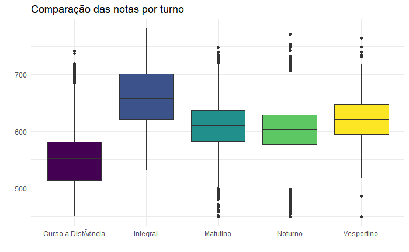

```r
dados_cursos %>%
  select(nota_integral_ampla, turno) %>%
  drop_na() %>%
  ggplot() +
  aes(x = turno ,y = nota_integral_ampla, fill = turno) +
  geom_boxplot(show.legend = FALSE) +
  labs(
    title = "Comparação das notas por turno",
    x = "",
    y = ""
  ) +
  scale_fill_viridis_d() +
  theme_minimal()
```

**a)** A maior mediana é a do turno integral, visto que contém uma maior concentração de notas altas, enquanto os outros turnos mesmo com algumas notas altas suas medianas não são alteradas por conta desses outliers,já que estão distante das notas da maioria.

**b)**Sumarizando a media e mediana, temos que a média do turno integral é 663.1000, e a mediana é de 657.50

```r
dados_cursos %>%
group_by(turno) %>%
  summarise(media_nota =
    mean(nota_integral_ampla,na.rm=TRUE),
mediana_nota = median(nota_integral_ampla,na.rm=TRUE)
)
```

| turno | media_nota | mediana_nota |
| --- | --- | --- |
| Curso a DistÃ¢ncia | 544.7927 | 551.94 |
| Integral | 663.1000 | 657.50 |
| Matutino | 609.1443 | 609.72 |
| Noturno | 601.8865 | 602.38 |
| Vespertino | 622.0320 | 620.57 |

**c)**O curso que possui menor homogeneidade é o Curso a distância.

```r
dados_cursos %>%
group_by(turno) %>%
  summarise(media_nota =
    mean(nota_integral_ampla,na.rm=TRUE),
mediana_nota = median(nota_integral_ampla,na.rm=TRUE),
desvio_nota = sd(nota_integral_ampla,na.rm = TRUE),
cv = (desvio_nota/media_nota)*100
)
```

| turno | media_nota | mediana_nota | desvio_nota | cv |
| --- | --- | --- | --- | --- |
| Curso a DistÃ¢ncia | 544.7927 | 551.94 | 53.24330 | 9.773131 |
| Integral | 663.1000 | 657.50 | 57.99986 | 8.746773 |
| Matutino | 609.1443 | 609.72 | 43.48318 | 7.138405 |
| Noturno | 601.8865 | 602.38 | 41.22816 | 6.849823 |
| Vespertino | 622.0320 | 620.57 | 40.98488 | 6.588870 |

**d)**Gráfico das notas

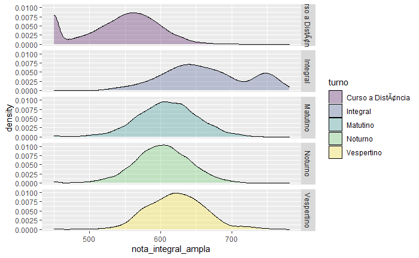

```r
dados_cursos %>%
  ggplot() +
  aes(x = nota_integral_ampla) +
  geom_density(aes(fill = turno), alpha = 0.3) +
  facet_grid(turno~.) +
  scale_fill_viridis_d()
```

Sim.Pois ela nos dá uma visualização bem coerente com as médias e medianas obtidas anteriormente,comfirmando assim que a densidade das distribuições das notas do curso a distância são inferiores do que as médias dos outros turnos, vemos também que o curso integral tem notas acima da média dos outros turnos, além de vizualizar como os turnos matutino, noturno e vespertino tem distribuição bastante simétricas em relação as suas médias e medianas.

**Questão 08.** Qual a posição ocupa o estado da Bahia, no que se refere à frequência absoluta da variável `uf_busca`, disposta de forma decrescente?